# Running Language Models Locally

#### NOTE: You can’t run this on Binder, which is why I have it as a separate file. If you download it and follow the instructions, you should be able to run this on your machine.

Language models pirated a lot of stuff to train these language models… They’ve trained a language model, and now they’re charging you for access to that stuff that was in the public domain in the first place. You can go and get one of those language models and tuck it in your back pocket, you can use it for your own data analysis, because the data that went into that language model was already in the public domain.  
**OLLAMA** runs language model tools locally on your computer. (Easier if you have a GPU, but not necessary.) Ollama is a wrapper around **Docker** - We’ll talk about this later! **Docker** essentially lets you run little computers on your computer.  
**Download link:** https://ollama.com/download

## Using OLLAMA

As mentioned, when we talk to the language model, we’ll talk to them over HTTP. So, `httr` provides us some functions to make requests over HTTP.

```r
library(httr)
# Gives HTTP response for Google
GET("www.google.com")
```

[output not shown]

### Install Instructions

1. **Install OLLAMA.** I have a Mac, so I installed it with Homebrew on my terminal: `brew install ollama`.
2. **Check the version** with `ollama -v`. You should see `ollama version is 0.12.6`.
3. **Pull or install a model locally:** `ollama pull gemma3:1b`.
4. **Run the OLLAMA API server:** `ollama serve`. If it says it’s already in use, check `lsof -i :11434`.

### Post Wrapper, Chat Completion, Factory

```r
library(httr)
library(jsonlite)

# Bottom-up: simple POST wrapper, then chat completion, then a factory

post <- function(url, body, headers=NULL) {
    req <- if (is.null(headers)) {
        httr::POST(url, body = body, encode = "json")
    } else {
        do.call(httr::POST, c(list(url = url, body = body, encode = "json"), headers))
    }
    jsonlite::fromJSON(httr::content(req, as = "text", encoding = "UTF-8"))
}


chat_completion <- function(base_url,
                            model,
                            user,
                            temperature = 0.7,
                            max_tokens = 256,
                            api_key = NULL,
                            path = "/chat/completions",
                            system = NULL,
                            extra = list()) {
  # Construct URL safely
  url <- paste0(base_url, path)

  # Add headers (if OpenAI-style API)
  headers <- if (!is.null(api_key) && nzchar(api_key)) {
    list(Authorization = paste("Bearer", api_key))
  } else {
    NULL
  }

  # Build message list for the API
  messages <- if (is.null(system)) {
    list(list(role = "user", content = user))
  } else {
    list(
      list(role = "system", content = system),
      list(role = "user", content = user)
    )
  }

  # Build JSON body
  body <- modifyList(list(
    model = model,
    messages = messages,
    temperature = temperature,
    max_tokens = max_tokens
  ), extra)

  # Send request
  res <- post(url, body, headers)

  # Safely extract assistant reply
  content <- tryCatch(
    res$choices$message$content[[1]],
    error = function(e) NULL
  )

  # Return structured result
  list(
    content = content,
    role = "assistant",
    raw = res
  )
}


chat_completion_factory <- function(base_url,
                                    model,
                                    api_key = NULL,
                                    path = "/chat/completions",
                                    defaults = list (temperature = 0.7, max_tokens = 256),
                                    extra = list()) {
    force(base_url); force(model); force(api_key); force(path); force(defaults); force(extra)
    function (user, system = defaults$system, ...,
           temperature = defaults$temperature, max_tokens = defaults$max_tokens) {
        chat_completion(
            base_url = base_url,
            model = model,
            user = user,
            temperature = temperature,
            max_tokens = max_tokens,
            api_key = api_key,
            path = path,
            system = defaults$system,
            extra = modifyList(extra, list(...))
        )
    }
}
```

### Using It

```r
# Choose endpoint and model
use_openai <- FALSE

base_url <- if (use_openai) "https://api.openai.com/v1" else "http://localhost:11434/v1"
api_key <- if (use_openai) Sys.getenv("OPENAI_API_KEY") else NULL # When you use OLLAMA, you don't need an API key.
model_name <- "gemma3:1b"

# Build a chat function with captured config
chat <- chat_completion_factory(base_url = base_url, model = model_name, api_key = api_key,
                                defaults = list(temperature = 0.7, max_tokens = 2000)
)

resp <- chat("It was the best of times")
cat(sprintf("%s\n", resp$content))
```

```
## Please provide me with the context! “It was the best of times” is a famous quote from Charles Dickens’ *A Tale of Two Cities*.
##
## I need to know what you're asking about before I can respond in a meaningful way.
##
## For example, are you:
##
## *   **Asking me to respond to the quote itself?** (e.g., "What does 'It was the best of times' mean?")
## *   **Asking me to explain the quote?** (e.g., "What does the quote suggest?")
## *   **Asking me to write something inspired by it?** (e.g., a poem, a story, a scene?)
##
## Let me know how I can help!
```

## Making Our Own Chat Bot

```r
# Closure-based chatbot that tracks conversation history
make_chatbot <- function(base_url, model,
                         api_key = NULL, system = NULL,
                         path = "/chat/completions",
                         defaults = list(temperature = 0.7, max_tokens = 2000),
                         extra = list()) {

  force(base_url); force(model); force(api_key); force(system); force(path); force(defaults); force(extra)

  history <- list()
  if (!is.null(system)) {
    history <- c(history, list(list(role = "system", content = system)))
  }

  function(user, temperature = defaults$temperature, max_tokens = defaults$max_tokens, ...) {
    history <<- c(history, list(list(role = "user", content = user)))

    url <- paste0(base_url, path)
    headers <- list(`Content-Type` = "application/json")
    if (!is.null(api_key) && nzchar(api_key)) {
      headers$Authorization <- paste("Bearer", api_key)
    }

    body <- c(list(
      model = model,
      messages = history,
      temperature = temperature,
      max_tokens = max_tokens
    ), modifyList(extra, list(...)))

    # Minimal fix: use do.call to expand the headers list
    res <- httr::POST(url,
                      do.call(httr::add_headers, headers),
                      body = jsonlite::toJSON(body, auto_unbox = TRUE))

    content <- httr::content(res)$choices[[1]]$message$content
    history <<- c(history, list(list(role = "assistant", content = content)))

    list(content = content, role = "assistant")
  }
}
```

### Using The DIY Chat Bot

```r
chatbot <- make_chatbot(
  base_url = base_url,
  model = model_name,
  api_key = api_key,
  system = "You are an intelligent, friendly assistant that can program in Python."
)

res <- chatbot("Explain how list comprehensions work, please.")
cat(sprintf("%s\n", res$content))
```

````
## Okay, let's break down list comprehensions in Python! They're a really powerful and concise way to create lists. Here's a breakdown, explaining the concepts and why they're so useful:
##
## **1. What is a List Comprehension?**
##
## At its core, a list comprehension is a single line of code that creates a list.  It's a way to create a list based on an existing iterable (like a list, tuple, or range) using a `for` loop and an expression.  Instead of writing multiple lines of code to build the list, you can combine them into a…
##
## **2. How it Works - The Syntax**
##
## The general syntax of a list comprehension is:
##
## ```python
## [expression for item in iterable if condition]
## ```
##
## Let's break down each part:
##
## * **`expression`**: This is the value that will be added to the new list. It's what you want to compute for each element.  It can be a simple calculation, a function call, or anything you want.
## * **`for item in iterable`**: This part iterates through each element in the `iterable`.  `item` represents the current element during each iteration.
## * **`if condition` (Optional)**: This is a conditional statement.  You can apply a filter to the elements before adding them to the list.  If the `condition` is `True`, the `item` is included in the new list.
##
## **3. Examples**
##
## Let's look at some practical examples:
##
## * **Creating a list of squares:**
##
##    ```python
##    numbers = [1, 2, 3, 4, 5]
##    squares = [x * x for x in numbers]
##    print(squares)  # Output: [1, 4, 9, 16, 25]
##    ```
##
##    In this example, we're creating a new list called `squares` by squaring each number in the `numbers` list.
##
## * **Filtering even numbers:**
##
##    ```python
##    numbers = [1, 2, 3, 4, 5, 6]
##    even_numbers = [x for x in numbers if x % 2 == 0]
##    print(even_numbers)  # Output: [2, 4, 6]
````

[output cut: 19 more lines]

```
##
## **5.  Key Considerations**
##
## * **Readability:** While concise, don't over-complicate a list comprehension.  If the logic becomes very complex, it might be better to use a regular `for` loop.
## * **Side Effects:** List comprehensions are best when they perform a transformation – you're not just creating a list, you're changing the elements *within* the list.
##
## **In short, list comprehensions are a powerful and elegant way to create lists in Python by combining a condition and an expression in a single, readable line of code.**
##
## ---
##
## **Do you want to dive deeper into a specific aspect of list comprehensions? For example, would you like to:**
##
## *   See more examples with different conditions?
## *   Understand how they compare to `for` loops?
## *   Explore nested list comprehensions (lists of lists, etc.)?
```

If we don’t understand the output, we can say:

```r
res1 <- chatbot("But what is a 'yield'?")
cat(sprintf("%s\n", res1$content))
```

````
## Okay, let’s talk about `yield` in Python! It’s a really important concept in the context of iterators and generators, and it’s often a source of confusion for beginners.
##
## **What is `yield`?**
##
## `yield` is a keyword that's used *inside* a function to create a *generator* function. A generator function doesn't immediately return a value; instead, it *yields* a value and then pauses its execution.  When the `next()` function is called on the generator, it resumes execution from where it le…
##
## **Here’s a breakdown of how it works:**
##
## 1. **Function Call:** You call a function that uses `yield`.
## 2. **Value is Generated:**  The function calculates and returns a value.
## 3. **Pause Execution:**  `yield` *pauses* the function's execution.
## 4. **Return Value:** The function returns the value.
## 5. **Resume Execution:**  The next time `next()` is called on the generator, execution resumes *from where it left off* after the `yield` statement.
## 6. **Next Value:** The next value is yielded.
##
## **Key Differences Between `yield` and `return`**
##
## | Feature           | `return` | `yield` |
## |--------------------|---------|---------|
## | Purpose           | Returns a value | Generates a value |
## | Side Effect       | Stops execution | Pauses execution |
## |  Reusability       | Cannot be reused | Can be reused |
## |  Iteration         | Stops iteration | Continues iteration |
##
## **Why Use `yield`?**
##
## * **Memory Efficiency:** Generators are incredibly memory-efficient. They don't store the entire sequence of values in memory, only the values they produce. This is especially important when dealing with large datasets.
## * **Lazy Evaluation:** The values are generated only when they are needed.  This is useful when you only need a subset of the values from a sequence.
## * **Code Readability:** Generators can make code more readable, especially when you want to create a sequence of values without having to explicitly construct the entire sequence.
##
## **Example:**
##
## ```python
## def my_generator(n):
##     for i in range(n):
##         yield i  # Yield each value in the range
##
## for value in my_generator(5):
##     print(value)  # Output: 0, 1, 2, 3, 4
## ```
##
## In this example, `my_generator` is a generator function.  It yields the values `0`, `1`, `2`, `3`, and `4` one by one.  The loop continues until `n` is reached, and then the function returns.
##
## **In essence, `yield` is a way to create an iterator that produces values on demand, rather than returning them all at once.**
##
## ---
##
## **Do you have any questions about `yield` that you'd like me to address? For example, would you like to:**
##
## *   See more examples of using `yield` in different contexts (e.g., `yield from`)?
## *   Understand how `yield` relates to iterators?
````

## Using Language Models For Data Science

There are two ways, embeddings and using the language model’s output.

### Embeddings

Language models have to transform their data into numbers in order to actually do their jobs. This is the first stage of processing that the input text gets when it is fed into the model and it is called “embedding.” It’s called an embedding because it **embeds free text into a representation that’s useful for the neural network**. The embeddings are learned as part of the training process and consequently they contain a lot of information about the text passed in, but unlike text, they can be used as vectors (approximately) and are thus amenable to many of the methods we discussed in class. We can get embeddings from our llama_cp model like this:

Before running, do the following on your terminal `ollama pull nomic-embed-text`.

```r
library(httr)
library(jsonlite)

embeddings <- function(base_url, model, input, api_key = NULL, path = "/embeddings", extra = list()) {
  url <- paste0(base_url, path)
  headers <- list(`Content-Type` = "application/json")
  if (!is.null(api_key) && nzchar(api_key)) {
    headers$Authorization <- paste("Bearer", api_key)
  }
  body <- c(list(model = model, input = input), extra)
  res <- httr::POST(url, do.call(httr::add_headers, headers), body = jsonlite::toJSON(body, auto_unbox = TRUE))
  parsed <- jsonlite::fromJSON(httr::content(res, as = "text", encoding = "UTF-8"))
  if (!is.null(parsed$data)) {
    if (is.data.frame(parsed$data) && "embedding" %in% names(parsed$data)) return(parsed$data$embedding)
    if (is.list(parsed$data)) return(lapply(parsed$data, function(x) x$embedding))
  }
  parsed
}

embeddings_factory <- function(base_url, model, api_key = NULL, path = "/embeddings", extra = list()) {
  force(base_url); force(model); force(api_key); force(path); force(extra)
  function(input, ...) {
    embeddings(
      base_url = base_url,
      model = model,
      input = input,
      api_key = api_key,
      path = path,
      extra = modifyList(extra, list(...))
    )
  }
}

embedding_request <- function(model, inputs, provider = c("openai", "ollama"), base_url = NULL) {
  provider <- match.arg(provider)
  if (is.null(base_url)) base_url <- if (provider == "openai") "https://api.openai.com/v1" else "http://localhost:11434/v1"
  embeddings(
    base_url = base_url,
    model = model,
    input = inputs,
    api_key = if (provider == "openai") Sys.getenv("OPENAI_API_KEY") else NULL
  )
}

use_openai <- FALSE
base_url <- if (use_openai) "https://api.openai.com/v1" else "http://localhost:11434/v1"
api_key <- if (use_openai) Sys.getenv("OPENAI_API_KEY") else NULL
model_name <- if (use_openai) "text-embedding-3-small" else "nomic-embed-text"

embed <- embeddings_factory(base_url = base_url, model = model_name, api_key = api_key)

emb <- embed(c(
  "It was the best of times.",
  "It was the worst of times."
))

txt <- jsonlite::toJSON(emb, auto_unbox = TRUE)
print(substr(txt, 1, 300))
```

```
## [[0.0775,0.0409,-0.1986,-0.0075,0.0237,0.0175,-0.0532,-0.0236,0.0291,0.0289,0.0108,-0.0074,0.0317,-0.0138,0.0052,-0.0712,0.0082,-0.0026,0.003,0.0512,0.0111,-0.0794,-0.0015,0.0289,0.0537,0.0255,-0.0349,0.0542,-0.035,-0.0145,0.0361,-0.0245,0.036,-0.0228,0.0054,-0.0387,-0.0247,0.0288,0.0411,-0.065,0…
```

Data science is all about dimensionality reduction, and clustering, and classification, and all of those things need numbers, and the embeddings give us numbers for text, which is great, we can do stuff with it.

### Calculating Embeddings for Each Paragraph

```r
library(httr)
library(tokenizers)

fetch_and_split_paragraphs <- function(url) {
  response <- httr::GET(url)
  text <- httr::content(response, as = "text", encoding = "UTF-8")
  text <- gsub("\r\n", "\n", text)
  text <- gsub("\r", "\n", text)
  tokenize_paragraphs(text, paragraph_break = "\n\n", simplify = TRUE)
}

tnl_paragraphs <- fetch_and_split_paragraphs("https://www.gutenberg.org/cache/epub/10662/pg10662.txt")
head(tnl_paragraphs)
```

```
## [1] "The Project Gutenberg eBook of The Night Land      This ebook is for the use of anyone anywhere in the United States and most other parts of the world at no cost and with almost no restrictions whatsoever. You may copy it, give it away or re-use it under the terms of the Project Gutenberg Li…
## [2] "Title: The Night Land"
## [3] "Author: William Hope Hodgson"
## [4] "Release date: January 1, 2004 [eBook #10662]                 Most recently updated: May 11, 2025"
## [5] "Language: English"
## [6] "Credits: Produced by Suzanne Shell, Maria Khomenko and PG Distributed Proofreaders"
```

```r
es <- embed(tnl_paragraphs[1:10])
print(substr(jsonlite::toJSON(es, auto_unbox = TRUE), 1, 200))
```

```
## [[0.0314,0.037,-0.1917,-0.007,-0.0155,0.0606,-0.0978,0.041,-0.0036,0.0087,0.0239,-0.0188,0.0178,0.0264,0.0115,-0.0017,-0.0131,0.0339,-0.0045,0.0037,-0.0332,-0.0333,-0.031,-0.0248,0.0514,0.0253,0.0252,
```

```r
library(jsonlite)
library(digest)

CACHE_DIR <- "embedding_cache"
if (!dir.exists(CACHE_DIR)) dir.create(CACHE_DIR)

get_cache_path <- function(text) file.path(CACHE_DIR, paste0(digest(text, algo = "md5"), ".json"))

get_embedding <- function(text, model = model_name) {
  cache_path <- get_cache_path(text)
  if (file.exists(cache_path)) return(jsonlite::fromJSON(cache_path))
  vec <- embed(text)[[1]]
  write(jsonlite::toJSON(vec, auto_unbox = TRUE), cache_path)
  vec
}

print(length(tnl_paragraphs))
```

```
## [1] 2367
```

```r
tnl_paragraphs <- tnl_paragraphs[nchar(tnl_paragraphs) > 50]
print(length(tnl_paragraphs))
```

```
## [1] 2311
```

```r
embeddings <- lapply(tnl_paragraphs, get_embedding)
```

Now, we can do things with this - like PCA!

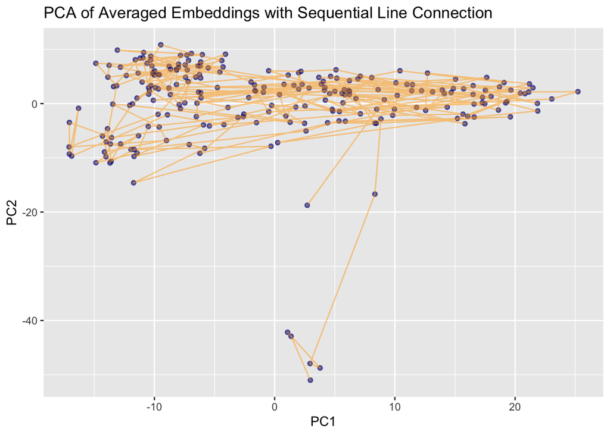

```r
library(ggplot2)

chunk_and_average_embeddings <- function(embeddings, paragraphs, chunk_size = 30) {
  chunked_embeddings <- list()
  chunked_paragraphs <- character()
  n <- length(embeddings)
  for (i in seq(1, n, by = chunk_size)) {
    idx <- i:min(i + chunk_size - 1, n)
    mats <- lapply(embeddings[idx], function(x) {
      v <- suppressWarnings(as.numeric(unlist(x)))
      if (any(is.na(v) | is.infinite(v))) return(NULL)
      v
    })
    mats <- mats[!sapply(mats, is.null)]
    if (length(mats) == 0) next
    mat <- do.call(rbind, mats)
    avg_embedding <- colMeans(mat, na.rm = TRUE)
    chunked_embeddings[[length(chunked_embeddings) + 1]] <- avg_embedding
    chunked_paragraphs <- c(chunked_paragraphs, paragraphs[i])
  }
  list(chunked_embeddings, chunked_paragraphs)
}

tmp <- chunk_and_average_embeddings(embeddings, tnl_paragraphs, chunk_size = 10)
avg_embeddings <- tmp[[1]]
avg_paragraphs <- tmp[[2]]

mat <- do.call(rbind, avg_embeddings)
mat <- mat[complete.cases(mat), ]

pca <- prcomp(mat, center = TRUE, scale. = TRUE)
coords <- as.data.frame(pca$x[, 1:2])
names(coords) <- c("x", "y")
coords$paragraph <- avg_paragraphs[seq_len(nrow(coords))]
coords$seq <- seq_len(nrow(coords))

print(ggplot(coords, aes(x = x, y = y)) +
  geom_point(color = "navy", alpha = 0.6) +
  geom_path(aes(group = 1), color = "orange", alpha = 0.5) +
  ggtitle("PCA of Averaged Embeddings with Sequential Line Connection") +
  xlab("PC1") + ylab("PC2"))
```

More agressive dimensionality reduction…

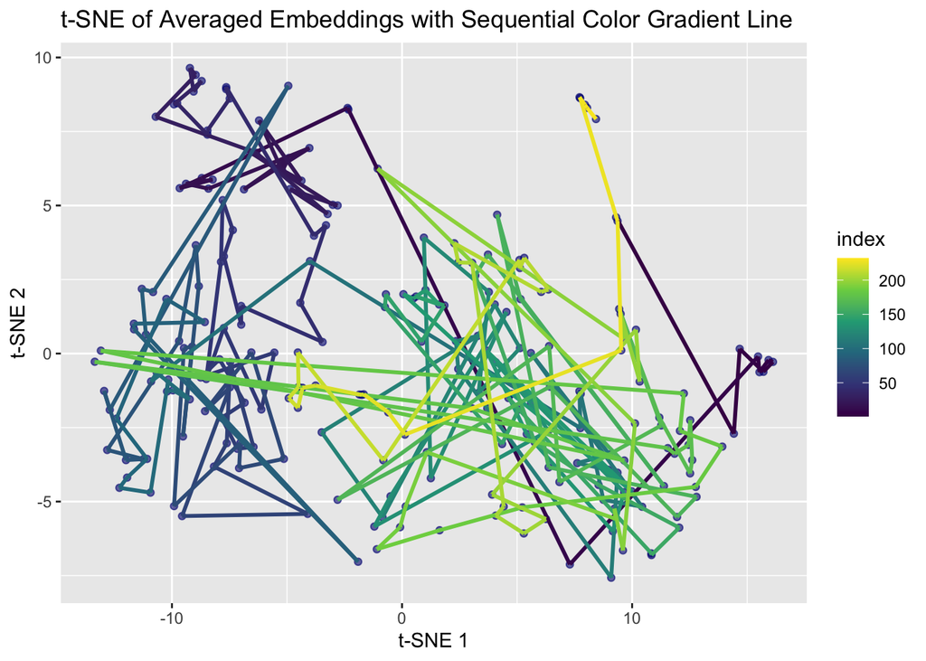

```r
library(Rtsne)
library(ggplot2)
library(viridis)
chunk_and_average_embeddings <- function(embeddings, paragraphs, chunk_size = 10) {
  chunked_embeddings <- list()
  chunked_paragraphs <- character()
  n <- length(embeddings)
  for (i in seq(1, n, by = chunk_size)) {
    idx <- i:min(i + chunk_size - 1, n)
    mats <- lapply(embeddings[idx], function(x) {
      v <- suppressWarnings(as.numeric(unlist(x)))
      if (any(is.na(v) | is.infinite(v))) return(NULL)
      v
    })
    mats <- mats[!sapply(mats, is.null)]
    if (length(mats) == 0) next
    mat <- do.call(rbind, mats)
    avg_embedding <- colMeans(mat, na.rm = TRUE)
    chunked_embeddings[[length(chunked_embeddings) + 1]] <- avg_embedding
    chunked_paragraphs <- c(chunked_paragraphs, paragraphs[i])
  }
  list(chunked_embeddings, chunked_paragraphs)
}

tmp <- chunk_and_average_embeddings(embeddings, tnl_paragraphs, chunk_size = 10)
avg_embeddings <- tmp[[1]]
avg_paragraphs <- tmp[[2]]
avg_mat <- do.call(rbind, avg_embeddings)
avg_mat <- avg_mat[complete.cases(avg_mat), ]

tsne <- Rtsne::Rtsne(avg_mat, dims = 2, perplexity = 30, verbose = FALSE)
coords <- as.data.frame(tsne$Y)
names(coords) <- c("x", "y")
coords$index <- seq_len(nrow(coords))

print(ggplot(coords, aes(x = x, y = y)) +
  geom_point(color = "navy", alpha = 0.6) +
  geom_path(aes(color = index, group = 1), linewidth = 1) +
  scale_color_viridis_c() +
  ggtitle("t-SNE of Averaged Embeddings with Sequential Color Gradient Line") +
  xlab("t-SNE 1") + ylab("t-SNE 2"))
```